# Practical Machine Learning

Juan Carlos Martinez

November 19, 2015

# Introduction

Use data collected form different body sensors to predict the quality of given excercise. This data is collected from http://groupware.les.inf.puc-rio.br/har Where more information can be found.

# Preprocessing

### Loading the data

```r
training <- read.csv("pml-training.csv")
testing <- read.csv("pml-testing.csv")
```

### Explaining the data set

The authors collected information from 4 sensors: *arm*, *dumbbell*, *belt* and *forearm*. Data was collected as a time series, where every 1 sec, a row containing statistical summaries from the current 1-sec window is set. This row is identified by the value *yes* on the column *new_window*. It is important to realize that for all other rows, the ones marked as *new_window=no*, there are missing values for all of the statistical summaries columns. The 20-samples on the *testing* set do not contain any of this special rows.

It is justified then to safely ignore the statitical *new_window=yes* rows, and of course, as a consecuence, to ignore the statistical columns.

This simplification leads to the following variables collected for each sensor: * roll * pitch * yaw * gyros x,y,z * accel x,y,z * total_accel * magnet x,y,z

```r
training <- filter(training, new_window=="no")

data <- training[,grep("^roll_|^pitch_|^yaw|^total_accel|^gyros_|^accel_|^magnet_|user_name|classe|X", names(training), value=TRUE)]
names(data)
```

```
##  [1] "X"                    "user_name"            "roll_belt"
##  [4] "pitch_belt"           "yaw_belt"             "total_accel_belt"
##  [7] "gyros_belt_x"         "gyros_belt_y"         "gyros_belt_z"
## [10] "accel_belt_x"         "accel_belt_y"         "accel_belt_z"
## [13] "magnet_belt_x"        "magnet_belt_y"        "magnet_belt_z"
## [16] "roll_arm"             "pitch_arm"            "yaw_arm"
## [19] "total_accel_arm"      "gyros_arm_x"          "gyros_arm_y"
## [22] "gyros_arm_z"          "accel_arm_x"          "accel_arm_y"
## [25] "accel_arm_z"          "magnet_arm_x"         "magnet_arm_y"
## [28] "magnet_arm_z"         "roll_dumbbell"        "pitch_dumbbell"
## [31] "yaw_dumbbell"         "total_accel_dumbbell" "gyros_dumbbell_x"
## [34] "gyros_dumbbell_y"     "gyros_dumbbell_z"     "accel_dumbbell_x"
## [37] "accel_dumbbell_y"     "accel_dumbbell_z"     "magnet_dumbbell_x"
## [40] "magnet_dumbbell_y"    "magnet_dumbbell_z"    "roll_forearm"
## [43] "pitch_forearm"        "yaw_forearm"          "total_accel_forearm"
## [46] "gyros_forearm_x"      "gyros_forearm_y"      "gyros_forearm_z"
## [49] "accel_forearm_x"      "accel_forearm_y"      "accel_forearm_z"
## [52] "magnet_forearm_x"     "magnet_forearm_y"     "magnet_forearm_z"
## [55] "classe"
```

### Outliers

Each of the variables was plotted in the following way

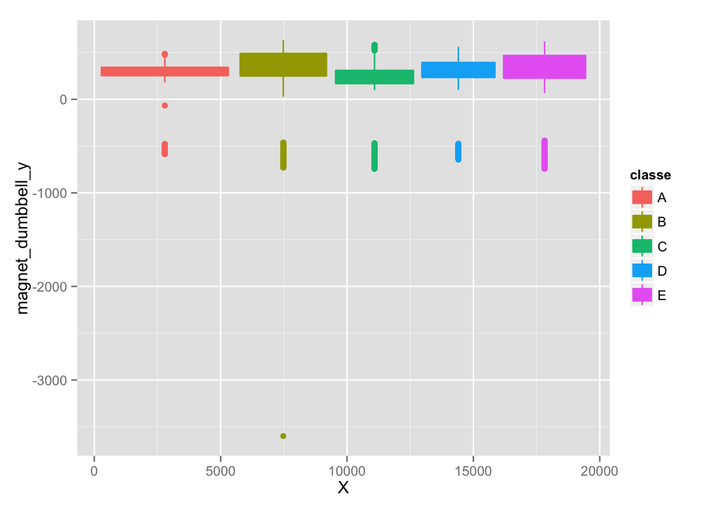

```r
qplot(x=X, y=magnet_dumbbell_y , data=data, color=classe, fill=classe, geom=c("boxplot") )
```

This lead to the discovery of 3 big outliers that are so big we can safely remove them. *Plots for all variables are not shown on this document.*

```r
data = data[-9088,]
data = data[-5270,]
data = data[-149,]
```

### Exploring data

Plotting a couple of sensors, coloring by class:

#### magnet_dumbbell_y

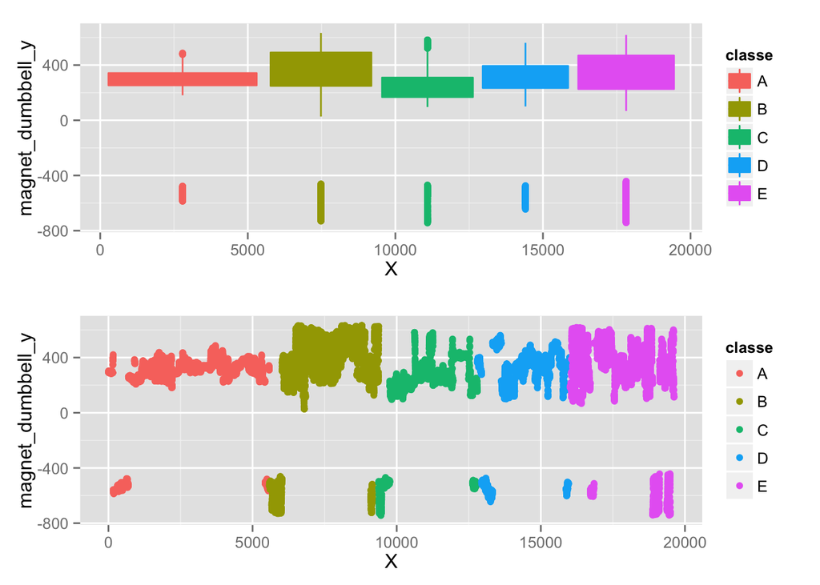

```r
p1 <- qplot(x=X, y=magnet_dumbbell_y , data=data, color=classe, fill=classe, geom=c("boxplot") )
p2 <- qplot(x=X, y=magnet_dumbbell_y , data=data, color=classe, fill=classe)
grid.arrange(p1,p2,nrow=2)
```

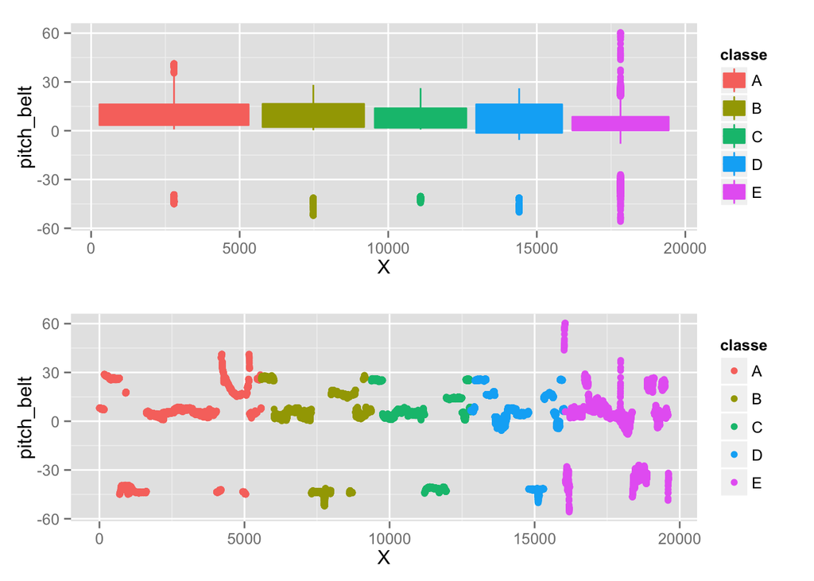

```r
p1 <- qplot(x=X, y=pitch_belt , data=data, color=classe, fill=classe, geom=c("boxplot") )
p2 <- qplot(x=X, y=pitch_belt , data=data, color=classe, fill=classe)
grid.arrange(p1,p2,nrow=2)
```

These plots show a lot of variabilty within the same *classe*, and almost no variability among them. **This seems like a though task for a predictioner**. Let us see how this unfolds.

### Constructing the features set

After plotting all variables on the same manner (not shown on this doc), we don’t see any single variable that stands out with a strong relation with *classe*, so, except for the extra computational cost, we are going to predict *classe* using all sensor variables:

```r
z <- paste(grep("^roll_|^pitch_|^yaw|^total_accel|^gyros_|^accel_|^magnet_", names(data), value=TRUE ), collapse="+")
formula <- paste("classe ~ ", z, collapse="")
formula
```

[output not shown]

# Training models

### Training Options

We are going to use *5-folds* *CrossValidation*, with *3 repats* and training size of *60%* . These parameters were choosen to reduce computation time.

#### A 5000 subsample try

```r
sdata = data[sample(nrow(data), 5000),]
```

Given the “decision-nature” of the question, tree-like algorithms are a good fit.

#### Random forest

```r
mod <- train(as.formula(formula), data=sdata, trControl=trainControl(method="cv", number=5, repeats=3, verboseIter=FALSE, p=0.6, allowParallel=TRUE), verbose=FALSE, method="rf")
predictions <- predict(mod, newdata=data)
confusionMatrix(predictions, data$classe)
```

```
## Confusion Matrix and Statistics
##
##           Reference
## Prediction    A    B    C    D    E
##          A 5440   56    0    1    4
##          B   12 3624   64   13   16
##          C   10   32 3250   49    8
##          D    4    3   37 3076   21
##          E    3    2    1    8 3479
##
## Overall Statistics
##
##                Accuracy : 0.9821
##                  95% CI : (0.9801, 0.9839)
##     No Information Rate : 0.2847
##     P-Value [Acc > NIR] : < 2.2e-16
##
##                   Kappa : 0.9773
##  Mcnemar's Test P-Value : 2.966e-13
##
## Statistics by Class:
##
##                      Class: A Class: B Class: C Class: D Class: E
## Sensitivity            0.9947   0.9750   0.9696   0.9774   0.9861
## Specificity            0.9956   0.9932   0.9938   0.9960   0.9991
## Pos Pred Value         0.9889   0.9718   0.9704   0.9793   0.9960
## Neg Pred Value         0.9979   0.9940   0.9936   0.9956   0.9969
## Prevalence             0.2847   0.1935   0.1745   0.1638   0.1836
## Detection Rate         0.2831   0.1886   0.1692   0.1601   0.1811
## Detection Prevalence   0.2863   0.1941   0.1743   0.1635   0.1818
## Balanced Accuracy      0.9951   0.9841   0.9817   0.9867   0.9926
```

We get pretty good results with this subset.

When increasing the sample size, results get better (**not shown in this doc**). We see high accuracy, with a good confidence interval.

### TreeBag

Let us see another tree-like algorithm, to see if results can improve even more.

```r
mod <- train(as.formula(formula), data=sdata, trControl=trainControl(method="cv", number=5, repeats=3, verboseIter=FALSE, p=0.6, allowParallel=TRUE), verbose=FALSE, method="treebag")
predictions <- predict(mod, newdata=data)
confusionMatrix(predictions, data$classe)
```

```
## Confusion Matrix and Statistics
##
##           Reference
## Prediction    A    B    C    D    E
##          A 5425   71    0    6   11
##          B   13 3568   70   19   31
##          C   19   57 3246   55   15
##          D    8   15   34 3056   19
##          E    4    6    2   11 3452
##
## Overall Statistics
##
##                Accuracy : 0.9757
##                  95% CI : (0.9735, 0.9779)
##     No Information Rate : 0.2847
##     P-Value [Acc > NIR] : < 2.2e-16
##
##                   Kappa : 0.9693
##  Mcnemar's Test P-Value : < 2.2e-16
##
## Statistics by Class:
##
##                      Class: A Class: B Class: C Class: D Class: E
## Sensitivity            0.9920   0.9599   0.9684   0.9711   0.9785
## Specificity            0.9936   0.9914   0.9908   0.9953   0.9985
## Pos Pred Value         0.9840   0.9641   0.9570   0.9757   0.9934
## Neg Pred Value         0.9968   0.9904   0.9933   0.9943   0.9952
## Prevalence             0.2847   0.1935   0.1745   0.1638   0.1836
## Detection Rate         0.2824   0.1857   0.1689   0.1591   0.1797
## Detection Prevalence   0.2869   0.1926   0.1765   0.1630   0.1809
## Balanced Accuracy      0.9928   0.9757   0.9796   0.9832   0.9885
```

Result are a bit less good, but good enough. The added plus is that the **computation time is less than with RForest**.

# Final Model

For accuracy, let us chose Random Forest.

Running on the whole training set

```r
mod <- train(as.formula(formula), data=data, trControl=trainControl(method="cv", number=5, repeats=3, verboseIter=FALSE, p=0.6, allowParallel=TRUE), verbose=FALSE, method="rf")
mod$finalModel
```

```
##
## Call:
##  randomForest(x = x, y = y, mtry = param$mtry, verbose = FALSE)
##                Type of random forest: classification
##                      Number of trees: 500
## No. of variables tried at each split: 2
##
##         OOB estimate of  error rate: 0.36%
## Confusion matrix:
##      A    B    C    D    E  class.error
## A 5468    1    0    0    0 0.0001828488
## B   10 3705    2    0    0 0.0032284100
## C    0   14 3337    1    0 0.0044749403
## D    0    0   37 3108    2 0.0123927550
## E    0    0    0    3 3525 0.0008503401
```

The overral error rate and per class are really good.

# Estimating Out Of Sample Error

Let us do 10 random prediction tests with our model

```r
for (i in 1:10)
{

  tdata <- data[sample(nrow(data), 2000),]
  predictions <- predict(mod, newdata=tdata)
  cm <- confusionMatrix(predictions, tdata$classe)
  #print(cm)
  if (i==1)
    accum = cm$overall
  else
    accum = accum + cm$overall
}
```

```r
total <- accum /10
print(total)
```

```
##       Accuracy          Kappa  AccuracyLower  AccuracyUpper   AccuracyNull
##      1.0000000      1.0000000      0.9981573      1.0000000      0.2849500
## AccuracyPValue  McnemarPValue
##      0.0000000            NaN
```

# 20-sample Test

Finally, let’s predict the given test set:

```r
predictions <- predict(mod, newdata=testing)
#results <- cbind(testing, predictions)
print(predictions)
```

```
##  [1] B A B A A E D B A A B C B A E E A B B B
## Levels: A B C D E
```

The grading machine will decide!